# Determinants of a Healthy Diet of U.S. adults 2021-2021

```r
#### Reading the parquet file
food <- read_parquet("proc_data/food_final_morevars.parquet")
```

# 1 Introduction

Do our backgrounds influence how healthy we eat? This project uses three models to reveal how demographic factors affect sugar consumption, sodium intake, and the probability of a healthy diet in U.S. adults (20+).

# 2 SMART Questions

# 3 Data

**What We Eat in America Dietary Data? National Health and Nutrition Examination Survey (NHANES) August 2021-August 2023**

The “What We Eat in America” (WWEIA) dietary data, collected between August 2021 and August 2023, form part of the National Health and Nutrition Examination Survey (NHANES) conducted by the U.S. Centers for Disease Control and Prevention (CDC) in collaboration with the U.S. Department of Agriculture (USDA). This dataset provides nationally representative information on the types and quantities of foods and beverages consumed by individuals in the United States.(U.S. Department of Agriculture, Agricultural Research Service, 2024)

Data were collected through telephone-administered 24-hour dietary recalls using the USDA’s 5-Step Automated Multiple-Pass Method (AMPM), a structured interview protocol designed to enhance accuracy and reduce underreporting. Each participant completed up to two dietary recalls, in which they reported all foods, beverages (including water), and supplements consumed from midnight to midnight on the previous day. (Williams, Terry, Akinbami, Ansai, & Ogden, 2025)

Nutrient values were derived from the USDA Food and Nutrient Database for Dietary Studies (FNDDS), which provides standardized nutrient composition data for thousands of food items. The 2021–2023 WWEIA cycle was based on an updated survey design and modified questionnaires introduced after the COVID-19 pandemic to reflect changes in food consumption patterns and supply chains.

The following dietary variables were included in the analysis: Individual ID, USDA 8-digit food code, **Energy (kcal)**, **Protein (g)**, **Carbohydrates (g)**, **Total Sugars (g)**, **Dietary Fiber (g)**, **Total Fat (g)**, and **Sodium (mg)**.

To generate individual-level daily consumption data, all foods reported under the USDA 8-digit codes were aggregated by summing nutrient quantities per individual. This approach provides the total daily nutrient intake per participant, allowing for direct comparisons across individuals and demographic groups. Aggregation by total intake—rather than mean or per-meal intake—was chosen to capture complete daily nutritional exposure, consistent with standard NHANES analytical practices. Future analyses could disaggregate these data by food category (e.g., cereals or processed foods) to examine the consumption of items most affected by recent price increases.

Demographic information was obtained from NHANES demographic files and included: **Individual ID**, **Gender**, **Age**, **Race/Hispanic origin (including Non-Hispanic Asian)**, **Education level (adults 20+)**, **Marital status**, **Household size**, and **Family income-to-poverty ratio**.

Following USDA recommendations, the analytic sample was restricted to adults aged 20 years and older to minimize bias from unequal age distributions across ethnic groups, as children’s food intake is inherently lower. Pregnant women were excluded because of their distinct nutritional requirements and dietary behaviors.

While the WWEIA-NHANES data provide a robust and nationally representative source for dietary assessment, several limitations should be acknowledged. First, the 24-hour dietary recall method relies on self-reported information, which is subject to recall bias and under reporting or over reporting, particularly for foods perceived as unhealthy. Second, each participant’s recall represents only one or two days of intake, which may not fully capture habitual dietary patterns or seasonal variations. Third, the use of aggregated nutrient totals does not account for meal timing or contextual factors, such as eating location or preparation method. Finally, subgroup analyses, such as by ethnicity or income, may still be affected by smaller sample sizes and sampling variability.

Despite these limitations, WWEIA-NHANES remains one of the most comprehensive and reliable datasets for examining dietary intake and its relationship to demographic and socioeconomic characteristics in the U.S. population.

# 4 Model 1: Sugar intake

## 4.1 Distribution of sugar

The following graph shows the distribution of daily sugar intake in grams across the sample, constructed using representative survey weights. The distribution is strongly right-skewed: most individuals consume between 50 and 150 grams of sugar per day,7 while a small fraction report extremely high intakes, with values approaching 1,000 grams within a 24-hour period.

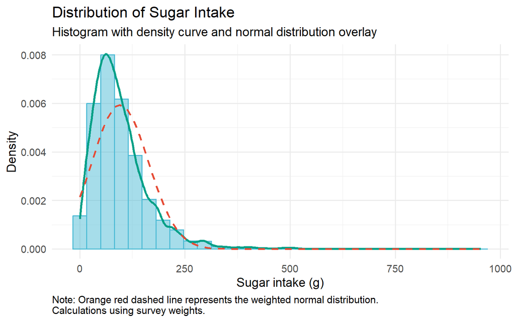

```r
survey_design <- svydesign(ids = ~1,weights = ~weight, data = food)
m_sugar  <- with(food, weighted.mean(sugar, weight, na.rm = TRUE))
sd_sugar <- with(food, {
  mu <- weighted.mean(sugar, weight, na.rm = TRUE)
  sqrt(weighted.mean((sugar - mu)^2, weight, na.rm = TRUE))
})

#Graph
ggplot(food, aes(x = sugar)) +
  geom_histogram(
    aes(
      y      = after_stat(density),
      weight = weight
    ),
    bins  = 30,
    alpha = 0.5,
    color = "#4DBBD5",
    fill  = "#4DBBD5"
  ) +
  geom_density(
    aes(weight = weight),
    color = "#00A087",
    size  = 1.2,
    alpha = 0.3,
    na.rm = TRUE
  ) +
  stat_function(
    fun  = dnorm,
    args = list(
      mean = m_sugar,
      sd   = sd_sugar
    ),
    color    = "#E64B35",
    size     = 1,
    linetype = "dashed"
  ) +
  labs(
    title    = "Distribution of Sugar Intake",
    subtitle = "Histogram with density curve and normal distribution overlay",
    x        = "Sugar intake (g)",
    y        = "Density",
    caption  = "Note: Orange red dashed line represents the weighted normal distribution.\nCalculations using survey weights."
  ) +
  theme_minimal(base_size = 14) +
  theme(
    plot.caption   = element_text(hjust = 0),
    legend.position = "bottom",
    strip.text      = element_text(face = "bold")
  )
```

To address this skewness, sugar intake is log-transformed, yielding a distribution that is more symmetric and closer to normal. However, because the logarithmic transformation compresses large values more strongly than small values, the transformation induces negative skewness in the presence of extreme upper-tail observations. As a result, the transformed variable departs from a symmetric Gaussian distribution, with a pronounced left tail.

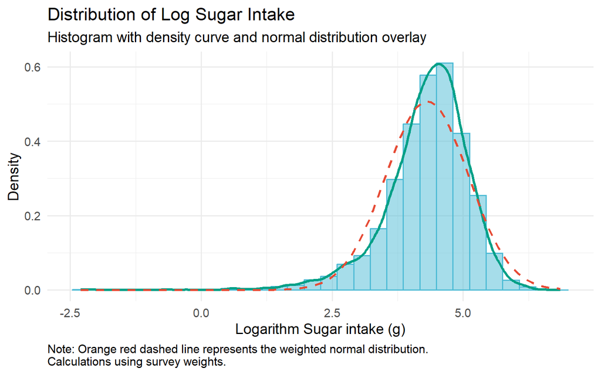

```r
#No missing in log sugar
df <- subset(food, is.finite(log_sugar) & !is.na(log_sugar))
survey_design <- svydesign(ids = ~1,weights = ~weight, data = food)

##### Distribution of Log of Sugar
## Weighted mean and sd for log_sugar
m_logsugar  <- with(df, weighted.mean(log_sugar, weight, na.rm = TRUE))
sd_logsugar <- with(df, {
  mu <- weighted.mean(log_sugar, weight, na.rm = TRUE)
  sqrt(weighted.mean((log_sugar - mu)^2, weight, na.rm = TRUE))
})

#Graph
ggplot(df, aes(x = log_sugar)) +
  geom_histogram(
    aes(
      y      = after_stat(density),
      weight = weight
    ),
    bins  = 30,
    alpha = 0.5,
    color = "#4DBBD5",
    fill  = "#4DBBD5"
  ) +
  geom_density(
    aes(weight = weight),
    color = "#00A087",
    size  = 1.2,
    alpha = 0.3,
    na.rm = TRUE
  ) +
  stat_function(
    fun  = dnorm,
    args = list(
      mean = m_logsugar,
      sd   = sd_logsugar
    ),
    color    = "#E64B35",
    size     = 1,
    linetype = "dashed"
  ) +
  labs(
    title    = "Distribution of Log Sugar Intake",
    subtitle = "Histogram with density curve and normal distribution overlay",
    x        = "Logarithm Sugar intake (g)",
    y        = "Density",
    caption  = "Note: Orange red dashed line represents the weighted normal distribution.\nCalculations using survey weights."
  ) +
  theme_minimal(base_size = 14) +
  theme(
    plot.caption   = element_text(hjust = 0),
    legend.position = "bottom",
    strip.text      = element_text(face = "bold")
  )
```

### 4.1.1 Sugar Outliers

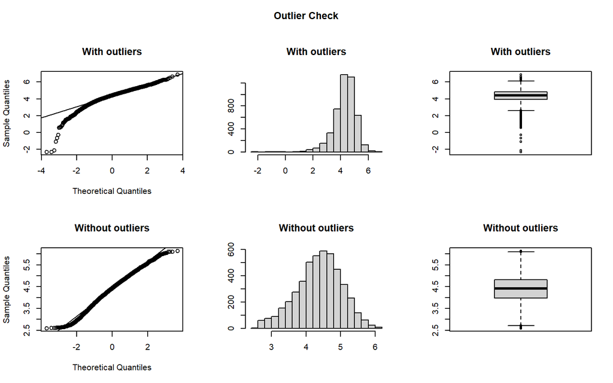

```
## Outliers identified: 160
## Proportion (%) of outliers: 3.5
## Mean of the outliers: 2.24
## Mean without removing outliers: 4.31
## Mean if we remove outliers: 4.38
## Outliers successfully removed
```

```r
### Outliers Log-Sugar
food_f = outlierKD2(df, log_sugar, rm = TRUE, boxplt = TRUE, qqplt = TRUE)
```

Achieving approximate normality would require excluding extreme observations, which would result in the removal of 3.5 percent of the sample. Importantly, excluding these observations would increase the mean level of sugar consumption, as average intake among the remaining sample is higher than in the full sample.

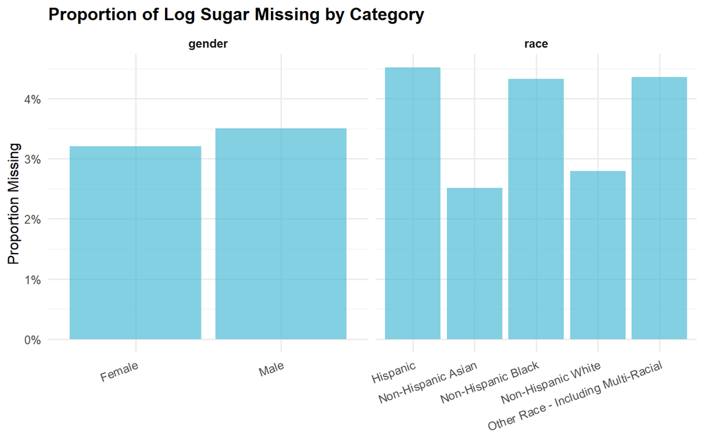

```r
cat_plot_data <- food_f %>%
  mutate(sugar_missing = is.na(log_sugar)) %>%
  pivot_longer(cols = c(gender, race),
               names_to = "variable",
               values_to = "category") %>%
  group_by(variable, category) %>%
  summarise(prop_missing = mean(sugar_missing), .groups = "drop")

cat_plot_data %>%
  mutate(category = str_to_title(category)) %>%
  ggplot(aes(x = category, y = prop_missing)) +
  geom_col(fill = "#4DBBD5", alpha=0.7) +
  facet_wrap(~ variable, scales = "free_x") +
  scale_y_continuous(labels = scales::percent) +
  labs(
    x = NULL,
    y = "Proportion Missing",
    title = "Proportion of Log Sugar Missing by Category"
  ) +
  theme_minimal(base_size = 12) +
  theme(
    axis.text.x = element_text(angle = 20, hjust = 1),
    plot.title = element_text(face = "bold"),
    strip.text = element_text(face = "bold")
  )
```

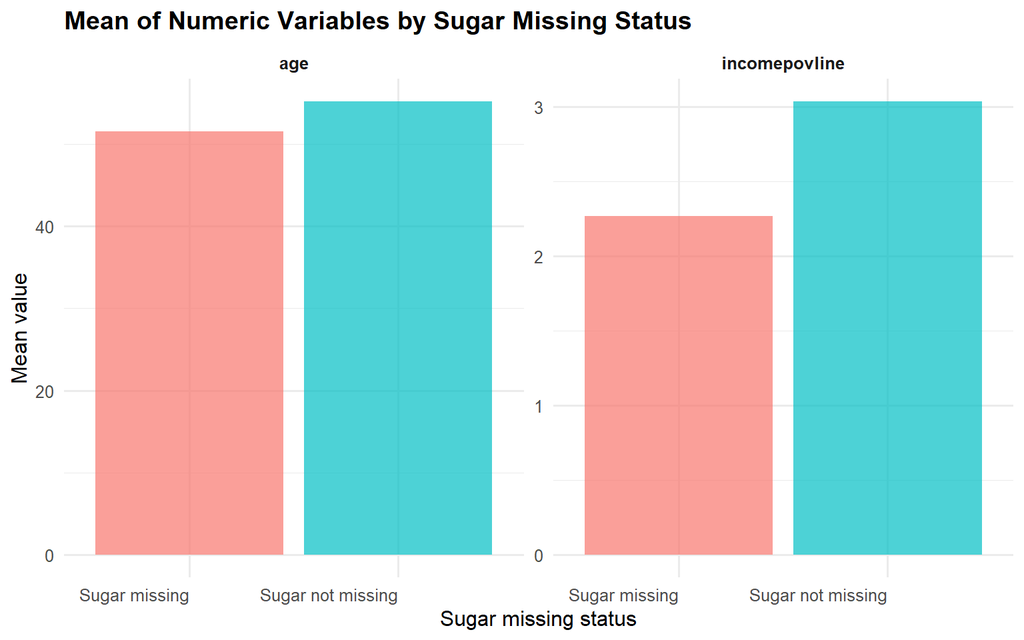

```r
num_plot_data <- food_f %>%
  mutate(sugar_missing = ifelse(is.na(log_sugar), "Sugar missing", "Sugar not missing")) %>%
  pivot_longer(cols = c(age, incomepovline),
               names_to = "variable",
               values_to = "value") %>%
  group_by(variable, sugar_missing) %>%
  summarise(mean_value = mean(value, na.rm = TRUE), .groups = "drop")

ggplot(num_plot_data,
          aes(x = sugar_missing, y = mean_value, fill = sugar_missing)) +
  geom_col(alpha=0.7) +
  facet_wrap(~ variable, scales = "free_y") +
  labs(
    x = "Sugar missing status",
    y = "Mean value",
    title = "Mean of Numeric Variables by Sugar Missing Status"
  ) +
  guides(fill = "none") +
  theme_minimal(base_size = 12) +
  theme(
    axis.text.x = element_text(hjust = 1),
    plot.title = element_text(face = "bold"),
    strip.text = element_text(face = "bold")
  )
```

Examination of the data indicates that these extreme observations are not randomly distributed. The excluded observations are disproportionately male, more likely to belong to racial and ethnic groups that are already underrepresented in the sample—particularly Hispanic, Black, and multiracial individuals—and are characterized by lower average age and income. Dropping these observations would therefore alter the demographic composition of the sample and reduce representativeness.

This presents a key modeling trade-off. Retaining the full sample implies using a dependent variable that does not fully satisfy the normality assumption underlying classical linear regression, potentially reducing efficiency and inflating standard errors. For this reason, we further examine the relationship between extreme sugar intake and demographic characteristics to assess whether these observations can be plausibly treated as random noise or whether their exclusion would introduce systematic bias.

## 4.2 Independent Variables

This section examines the bivariate relationships between daily sugar consumption and key independent variables.

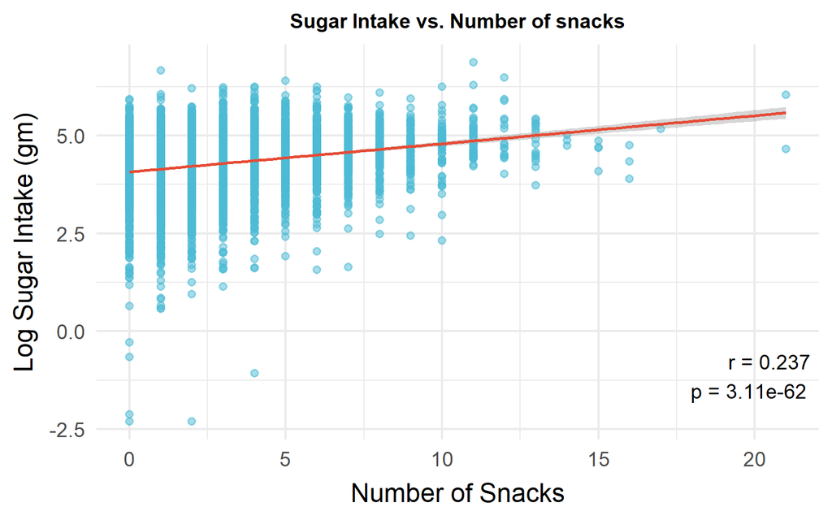

```r
##### Scatterplot of Sugar and Number of Snacks
ct <- cor.test(df$numsnacks, df$log_sugar, use = "complete.obs")
r_val <- unname(ct$estimate)   # Pearson r
p_val <- ct$p.value            # p-value
lab_text <- paste0("r = ", round(r_val, 3), "\n p = ", signif(p_val, 3))

ggplot(df, aes(x = numsnacks, y = log_sugar)) +
  geom_point(color = "#4DBBD5", alpha = 0.5, size = 2) +
  geom_smooth(method = "lm", se = TRUE, linewidth = 1, color = "#E64B35") +
  annotate(
    "text", x = Inf, y = 0, hjust  = 1.1, vjust  = 1.5, label  = lab_text, size   = 5
  ) +
  labs(
    title = "Sugar Intake vs. Number of snacks",
    x = "Number of Snacks",
    y = "Log Sugar Intake (gm)"
  ) +
  theme_minimal(base_size = 18) +
  theme(
    plot.title = element_text( hjust = 0.5, face = "bold", size = 14),
    axis.title.x = element_text(margin = margin(t = 8)),
    axis.title.y = element_text(margin = margin(r = 8))
  )
```

Sugar intake is positively associated with the number of snacks consumed during the 24-hour dietary recall period. The Pearson correlation coefficient is 0.237, with a p-value of 3.113^{-62}, allowing rejection of the null hypothesis of no linear association. This result suggests a statistically significant and non-random relationship between snack frequency and sugar intake.

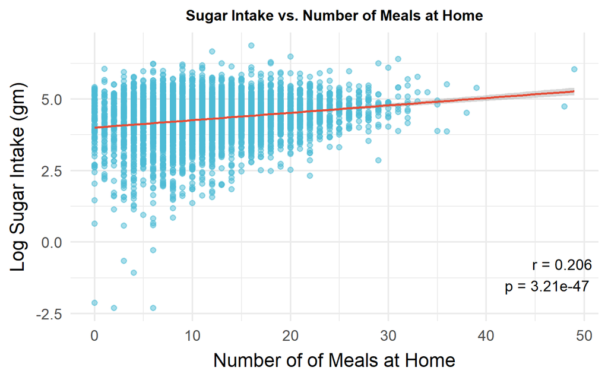

```r
##### Scatterplot of Sugar and Number of Meals at Home
ct <- cor.test(df$numhomemeals, df$log_sugar, use = "complete.obs")
r_val <- unname(ct$estimate)   # Pearson r
p_val <- ct$p.value            # p-value
lab_text <- paste0("r = ", round(r_val, 3), "\n p = ", signif(p_val, 3))

ggplot(df, aes(x = numhomemeals, y = log_sugar)) +
  geom_point(color = "#4DBBD5", alpha = 0.5, size  = 2) +
  geom_smooth(method = "lm", se = TRUE, linewidth = 1, color = "#E64B35") +
  annotate(
    "text", x = Inf, y = 0, hjust  = 1.1, vjust  = 1.5, label  = lab_text, size   = 5
  ) +
  labs(
    title = "Sugar Intake vs. Number of Meals at Home",
    x     = "Number of of Meals at Home",
    y     = "Log Sugar Intake (gm)") +
  theme_minimal(base_size = 18) +
  theme(
    plot.title   = element_text(hjust = 0.5,face  = "bold",size  = 14),
    axis.title.x = element_text(margin = margin(t = 8)),
    axis.title.y = element_text(margin = margin(r = 8))
  )
```

A positive association is also observed between sugar consumption and the number of meals consumed at home. The Pearson correlation coefficient is 0.206, with a p-value of 3.21^{-47}, indicating a statistically significant relationship. Although this finding contrasts with prior evidence linking home-prepared meals to healthier diets (Brown 2024), it may reflect a scale effect: individuals consuming more meals overall may also consume greater quantities of all nutrients, including sugar.

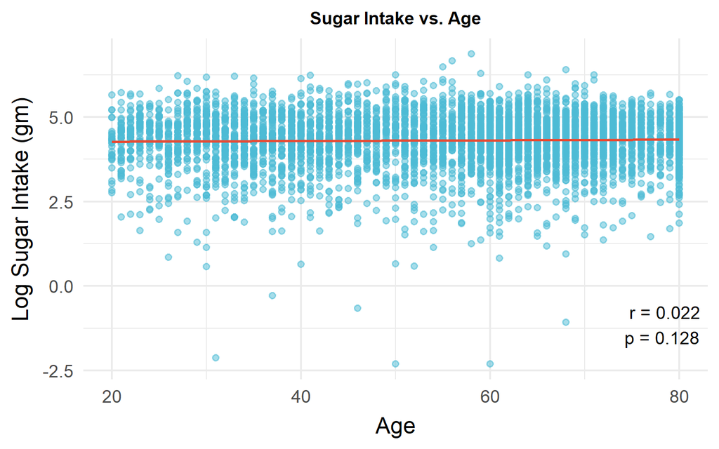

```r
##### Scatterplot of Sugar and Age
ct <- cor.test(df$age, df$log_sugar, use = "complete.obs")
r_val <- unname(ct$estimate)   # Pearson r
p_val <- ct$p.value            # p-value
lab_text <- paste0("r = ", round(r_val, 3), "\n p = ", signif(p_val, 3))

ggplot(df, aes(x = age, y = log_sugar)) +
  geom_point(color = "#4DBBD5", alpha = 0.5, size = 2) +
  geom_smooth(method = "lm", se = TRUE, linewidth = 1, color = "#E64B35") +
  annotate(
    "text", x = Inf, y = 0, hjust  = 1.1, vjust  = 1.5, label  = lab_text, size   = 5
  ) +
  labs(
    title = "Sugar Intake vs. Age",
    x = "Age",
    y = "Log Sugar Intake (gm)"
  ) +
  theme_minimal(base_size = 18) +
  theme(
    plot.title = element_text(hjust = 0.5, face = "bold", size = 14),
    axis.title.x = element_text(margin = margin(t = 8)),
    axis.title.y = element_text(margin = margin(r = 8))
  )
```

In contrast, age does not appear to be associated with sugar consumption. This is confirmed by a Pearson correlation coefficient of 0.022 and a p-value of 0.128, failing to reject the null hypothesis of no linear relationship.

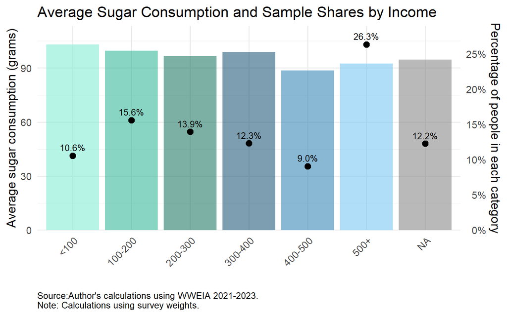

```r
my_colors <- c("<100"    = "#7AEBD1",
               "100-200"      = "#27B291",
               "200-300"      = "#12705A",
               "300-400"      = "#124E70",
               "400-500"      = "#277EB0",
               "500+" = "#6FC2F2",
               "NA" = "gray")


# ---- Prepare data: weighted sugar + within-variable shares ----
df_plot <- df %>%
  group_by(income_pov_cat) %>%
  summarise(
    weighted_n     = sum(weight, na.rm = TRUE),
    weighted_sugar = weighted.mean(sugar, weight, na.rm = TRUE),
    .groups = "drop"
  ) %>%
  mutate(
    prop  = weighted_n / sum(weighted_n),      # share within each variable
    share_label = percent(prop, accuracy = 0.1)
  ) %>%
  ungroup()
scale_factor <- max(df_plot$weighted_sugar, na.rm = TRUE) /
  max(df_plot$prop,           na.rm = TRUE)

df_plot <- df_plot %>%
  mutate(prop_scaled = prop * scale_factor)

# ---- Plot: ----
ggplot(df_plot, aes(x = income_pov_cat)) +
  geom_col(aes(y = weighted_sugar, fill = income_pov_cat, alpha = 0.4)) +
  geom_point(aes(y = prop_scaled), size = 3, color = "black") +
  geom_text(aes(y = prop_scaled, label = share_label),
            vjust = -0.7, size = 3.5) +
  scale_fill_manual(values = my_colors) +
  scale_y_continuous(
    name = "Average sugar consumption (grams)",
    expand = expansion(mult = c(0, 0.1)),
    sec.axis = sec_axis(
      ~ . / scale_factor,
      name = "Percentage of people in each category",
      breaks = seq(0, 1, by = 0.05),   # every 5%
      labels = percent_format()
    )
  ) +

  labs(
    title = "Average Sugar Consumption and Sample Shares by Income",
    caption = "Source:Author's calculations using WWEIA 2021-2023. \nNote: Calculations using survey weights.",
    x = "",
    fill = ""
  ) +
  theme_minimal(base_size = 14) +
  theme(
    legend.position = "none",
    axis.text.x = element_text(angle = 45, hjust = 1),
    plot.caption = element_text(hjust = 0, size = 10, margin = margin(t = 10))
  )
```

The previous figure presents average daily sugar consumption by income-to-poverty ratio category, reported in grams for ease of interpretation. Average sugar intake is relatively similar across income groups, at approximately 90 grams per day. The figure also displays the distribution of the sample across income categories. Approximately 10.6 percent of individuals live in households at or below 100 percent of the poverty line, while 29.6 percent fall between 100 and 300 percent—roughly corresponding to median household income in the United States. According to U.S. Census Bureau estimates, real median household income in 2024 was approximately $83,730, with an average household size of 3.15 persons, consistent with an income-to-poverty ratio near 300 percent. An additional 21.3 percent of the sample falls between 300 and 500 percent of the poverty line, and 26.3 percent resides in households at or above 500 percent.

```r
summary(aov(log_sugar ~ incomepovline, data=df))
```

```
##                 Df Sum Sq Mean Sq F value Pr(>F)
## incomepovline    1      1   0.565     0.9   0.34
## Residuals     4236   2670   0.630
## 555 observations deleted due to missingness
```

Differences in average sugar consumption across income groups are small and statistically insignificant. An ANOVA test yields a p-value of 0.34, failing to reject the null hypothesis that mean sugar intake is equal across income categories.

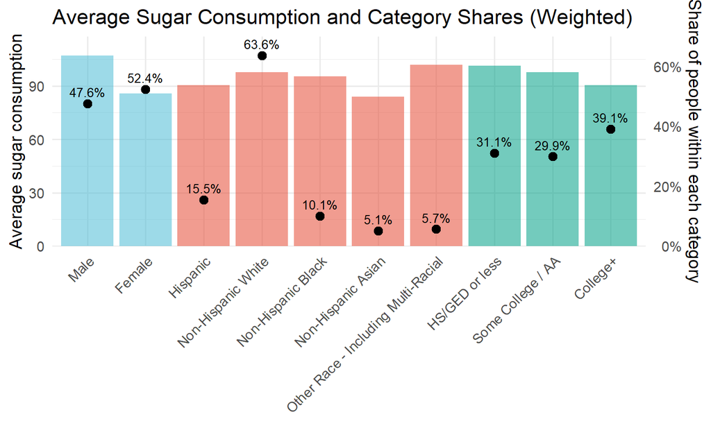

```r
my_colors <- c("gender"    = "#4DBBD5",
               "race"      = "#E64B35",
               "education" = "#00A087")


# ---- Prepare data: weighted sugar + within-variable shares ----
df_plot <- food %>%
  pivot_longer(
    cols = c(gender, race, education),
    names_to = "variable",
    values_to = "category"
  ) %>%
  group_by(variable, category) %>%
  summarise(
    weighted_n     = sum(weight, na.rm = TRUE),
    weighted_sugar = weighted.mean(sugar, weight, na.rm = TRUE),
    .groups = "drop"
  ) %>%
  group_by(variable) %>%
  mutate(
    prop  = weighted_n / sum(weighted_n),      # share within each variable
    share_label = percent(prop, accuracy = 0.1)
  ) %>%
  ungroup() %>%
  mutate(full_cat = paste(variable, category, sep = ": "))

# ---- Rescale share so dots can be plotted on sugar scale ----
scale_factor <- max(df_plot$weighted_sugar, na.rm = TRUE) /
  max(df_plot$prop,           na.rm = TRUE)

df_plot <- df_plot %>%
  mutate(prop_scaled = prop * scale_factor)

# ---- Plot----
ggplot(df_plot, aes(x = category)) +
  geom_col(aes(y = weighted_sugar, fill = variable, alpha = 0.4)) +
  geom_point(aes(y = prop_scaled), size = 3, color = "black") +
  geom_text(aes(y = prop_scaled, label = share_label),
            vjust = -0.7, size = 3.5) +
  scale_fill_manual(values = my_colors) +
  scale_y_continuous(
    name = "Average sugar consumption",
    expand = expansion(mult = c(0, 0.1)),
    sec.axis = sec_axis(
      ~ . / scale_factor,
      name   = "Share of people within each category",
      labels = percent_format()
    )
  ) +
  labs(
    title = "Average Sugar Consumption and Category Shares (Weighted)",
    x = "",
    fill = ""
  ) +
  theme_minimal(base_size = 14) +
  theme(
    legend.position = "none",
    axis.text.x = element_text(angle = 45, hjust = 1)
  )
```

This figure shows average sugar consumption by gender, race and ethnicity, and educational attainment.

```r
summary(aov(log_sugar ~ gender, data=df))
```

```
##               Df Sum Sq Mean Sq F value Pr(>F)
## gender         1     45    44.7    72.5 <2e-16 ***
## Residuals   4791   2955     0.6
## ---
## Signif. codes:  0 '***' 0.001 '**' 0.01 '*' 0.05 '.' 0.1 ' ' 1
```

Women, who comprise 52.4 percent of the sample, consume less sugar on average than men. This difference is statistically significant, with ANOVA results yielding a p-value below 2 × 10⁻¹⁶.

```r
anova_result = aov(log_sugar ~ race, data=df)
summary(anova_result)
```

```
##               Df Sum Sq Mean Sq F value Pr(>F)
## race           4     13    3.30    5.29  3e-04 ***
## Residuals   4788   2986    0.62
## ---
## Signif. codes:  0 '***' 0.001 '**' 0.01 '*' 0.05 '.' 0.1 ' ' 1
```

```r
tukeyAoV <- TukeyHSD(anova_result)
tukey_table <- tidy(tukeyAoV) %>%
  rename(
    Comparison = contrast,
    Mean_Difference = estimate,
    Lower_95CI = conf.low,
    Upper_95CI = conf.high,
    Adjusted_p = adj.p.value
  ) %>%
  mutate(Significance = ifelse(Adjusted_p < 0.05, "Significant", "Not Significant"))
kable(
  tukey_table,
  caption = "Tukey HSD Post-hoc Test for Sugar Intake Across Ethnic Groups",
  digits = 3,
  align = "lccccc"
)
```

Tukey HSD Post-hoc Test for Sugar Intake Across Ethnic Groups

| term | Comparison | null.value | Mean_Difference | Lower_95CI | Upper_95CI | Adjusted_p | Significance |
| --- | --- | --- | --- | --- | --- | --- | --- |
| race | Non-Hispanic White-Hispanic | 0 | 0.137 | 0.050 | 0.223 | 0.000 | Significant |
| race | Non-Hispanic Black-Hispanic | 0 | 0.089 | -0.031 | 0.209 | 0.255 | Not Significant |
| race | Non-Hispanic Asian-Hispanic | 0 | 0.024 | -0.147 | 0.195 | 0.996 | Not Significant |
| race | Other Race - Including Multi-Racial-Hispanic | 0 | 0.133 | -0.014 | 0.280 | 0.096 | Not Significant |
| race | Non-Hispanic Black-Non-Hispanic White | 0 | -0.048 | -0.147 | 0.052 | 0.690 | Not Significant |
| race | Non-Hispanic Asian-Non-Hispanic White | 0 | -0.113 | -0.271 | 0.045 | 0.291 | Not Significant |
| race | Other Race - Including Multi-Racial-Non-Hispanic White | 0 | -0.003 | -0.134 | 0.128 | 1.000 | Not Significant |
| race | Non-Hispanic Asian-Non-Hispanic Black | 0 | -0.065 | -0.243 | 0.113 | 0.856 | Not Significant |
| race | Other Race - Including Multi-Racial-Non-Hispanic Black | 0 | 0.044 | -0.110 | 0.199 | 0.936 | Not Significant |
| race | Other Race - Including Multi-Racial-Non-Hispanic Asian | 0 | 0.110 | -0.088 | 0.307 | 0.553 | Not Significant |

```r
summary(aov(log_sugar ~ education, data=df))
```

```
##               Df Sum Sq Mean Sq F value Pr(>F)
## education      2      1   0.553    0.88   0.41
## Residuals   4790   2998   0.626
```

Average sugar consumption declines with higher levels of educational attainment. However, despite this monotonic pattern, ANOVA results indicate that differences in mean sugar intake across education categories are not statistically significant.

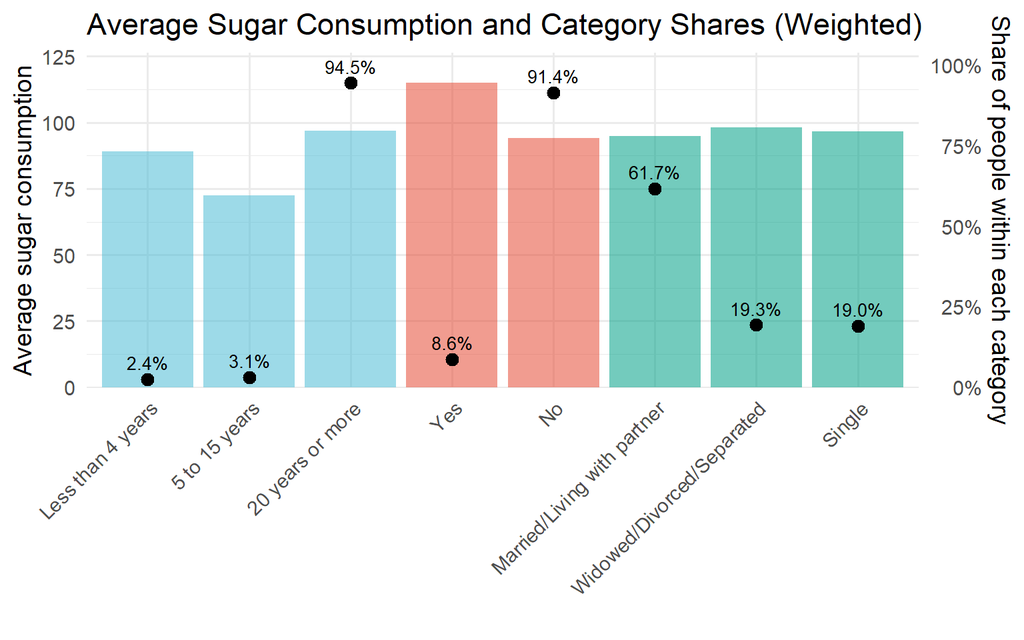

```r
my_colors <- c("timeus"    = "#4DBBD5",
               "militar"      = "#E64B35",
               "maritalstatus" = "#00A087")

df_plot <- food %>%
  pivot_longer(
    cols = c(timeus, militar, maritalstatus),
    names_to = "variable",
    values_to = "category"
  ) %>%
  group_by(variable, category) %>%
  summarise(
    weighted_n     = sum(weight, na.rm = TRUE),
    weighted_sugar = weighted.mean(sugar, weight, na.rm = TRUE),
    .groups = "drop"
  ) %>%
  group_by(variable) %>%
  mutate(
    prop  = weighted_n / sum(weighted_n),      # share within each variable
    share_label = percent(prop, accuracy = 0.1)
  ) %>%
  ungroup() %>%
  mutate(full_cat = paste(variable, category, sep = ": "))

# ---- Rescale share so dots can be plotted on sugar scale ----
scale_factor <- max(df_plot$weighted_sugar, na.rm = TRUE) /
  max(df_plot$prop,           na.rm = TRUE)

df_plot <- df_plot %>%
  mutate(prop_scaled = prop * scale_factor)

# ---- Plot----
ggplot(df_plot, aes(x = category)) +
  geom_col(aes(y = weighted_sugar, fill = variable, alpha = 0.4)) +
  geom_point(aes(y = prop_scaled), size = 3, color = "black") +
  geom_text(aes(y = prop_scaled, label = share_label),
            vjust = -0.7, size = 3.5) +
  scale_fill_manual(values = my_colors) +
  scale_y_continuous(
    name = "Average sugar consumption",
    expand = expansion(mult = c(0, 0.1)),
    sec.axis = sec_axis(
      ~ . / scale_factor,
      name   = "Share of people within each category",
      labels = percent_format()
    )
  ) +
  labs(
    title = "Average Sugar Consumption and Category Shares (Weighted)",
    x = "",
    fill = ""
  ) +
  theme_minimal(base_size = 14) +
  theme(
    legend.position = "none",
    axis.text.x = element_text(angle = 45, hjust = 1)
  )
```

```r
summary(aov(log_sugar ~ timeus, data=df))
```

```
##               Df Sum Sq Mean Sq F value Pr(>F)
## timeus         2      8    3.94    6.32 0.0018 **
## Residuals   4790   2991    0.62
## ---
## Signif. codes:  0 '***' 0.001 '**' 0.01 '*' 0.05 '.' 0.1 ' ' 1
```

```r
summary(aov(log_sugar ~ militar, data=df))
```

```
##               Df Sum Sq Mean Sq F value Pr(>F)
## militar        1     11   11.34    18.2  2e-05 ***
## Residuals   4791   2988    0.62
## ---
## Signif. codes:  0 '***' 0.001 '**' 0.01 '*' 0.05 '.' 0.1 ' ' 1
```

```r
summary(aov(log_sugar ~ maritalstatus, data=df))
```

```
##                 Df Sum Sq Mean Sq F value Pr(>F)
## maritalstatus    2      2   1.135    1.81   0.16
## Residuals     4790   2997   0.626
```

The majority of the sample has resided in the United States for 20 years or more. While some variation in sugar consumption is observed among individuals with shorter durations of residence, these groups represent a relatively small share of the sample. ANOVA results indicate statistically significant differences in sugar consumption by time spent in the United States.

Finally, individuals with military status report higher average sugar consumption than non-military respondents, and this difference is statistically significant. In contrast, average sugar consumption varies little across marital status categories, and ANOVA results fail to detect statistically significant differences.

## 4.3 Linear Model

The linear regression framework is chosen for its interpretability and its suitability for estimating conditional mean differences in sugar intake across demographic groups. Coefficients are estimated by ordinary least squares, and identification relies on within-sample variation in covariates after conditioning on the full set of controls.

### 4.3.1 Best Model ANOVA comparison

To select a parsimonious specification, we adopt a stepwise model-building approach, sequentially adding covariates and evaluating improvements in model fit. We begin with a baseline specification that includes only the number of snacks and the number of home-prepared meals, which capture key behavioral determinants of sugar intake. Additional covariates are incorporated if their inclusion improves model performance based on residual diagnostics and overall fit.

```r
#Benchmark
fit1 <- glm(log_sugar ~ numsnacks + numhomemeals, data = df)
# + gender
fit2 <- glm(log_sugar ~ numsnacks + numhomemeals + gender, data = df)
#anova(fit1,fit2)
# + education
fit3 <- glm(log_sugar ~ numsnacks + numhomemeals + gender + education, data = df)
#anova(fit1,fit2, fit3)
# + age
fit4 <- glm(log_sugar ~ numsnacks + numhomemeals + gender + education + age, data = df)
#anova(fit1,fit2, fit3, fit4)
# + age & age^2
fit5 <- glm(log_sugar ~ numsnacks + numhomemeals + gender + education + age + I(age^2), data = df)
anova(fit1,fit2, fit3, fit4, fit5)
```

```
## Analysis of Deviance Table
##
## Model 1: log_sugar ~ numsnacks + numhomemeals
## Model 2: log_sugar ~ numsnacks + numhomemeals + gender
## Model 3: log_sugar ~ numsnacks + numhomemeals + gender + education
## Model 4: log_sugar ~ numsnacks + numhomemeals + gender + education + age
## Model 5: log_sugar ~ numsnacks + numhomemeals + gender + education + age +
##     I(age^2)
##   Resid. Df Resid. Dev Df Deviance     F Pr(>F)
## 1      4790       2773
## 2      4789       2721  1     52.6 92.69 <2e-16 ***
## 3      4787       2715  2      5.0  4.43  0.012 *
## 4      4786       2713  1      2.1  3.75  0.053 .
## 5      4785       2713  1      0.3  0.62  0.432
## ---
## Signif. codes:  0 '***' 0.001 '**' 0.01 '*' 0.05 '.' 0.1 ' ' 1
```

The first set of demographic variables added includes gender and educational attainment. Both variables improve model fit and are retained. In contrast, age and a quadratic age term are not associated with improved model performance and are excluded, suggesting no meaningful linear or nonlinear relationship between age and sugar intake after accounting for other covariates.

```r
### New Benchmark
fit1 <- glm(log_sugar ~ numsnacks + numhomemeals + gender + education, data = df)
#+race
fit2 <- glm(log_sugar ~ numsnacks + numhomemeals + gender + education + race, data = df)
#anova(fit1,fit2)
#+timeus
fit3 <- glm(log_sugar ~ numsnacks + numhomemeals + gender + education + race +timeus, data = df)
#anova(fit1,fit2, fit3)
#maritalstatus
fit4 <- glm(log_sugar ~ numsnacks + numhomemeals + gender + education + race +timeus+maritalstatus, data = df)
anova(fit1,fit2, fit3, fit4)
```

```
## Analysis of Deviance Table
##
## Model 1: log_sugar ~ numsnacks + numhomemeals + gender + education
## Model 2: log_sugar ~ numsnacks + numhomemeals + gender + education + race
## Model 3: log_sugar ~ numsnacks + numhomemeals + gender + education + race +
##     timeus
## Model 4: log_sugar ~ numsnacks + numhomemeals + gender + education + race +
##     timeus + maritalstatus
##   Resid. Df Resid. Dev Df Deviance    F  Pr(>F)
## 1      4787       2715
## 2      4783       2705  4    10.50 4.64 0.00096 ***
## 3      4781       2702  2     3.44 3.04 0.04783 *
## 4      4779       2701  2     0.18 0.16 0.85559
## ---
## Signif. codes:  0 '***' 0.001 '**' 0.01 '*' 0.05 '.' 0.1 ' ' 1
```

The updated benchmark model is then augmented with race and ethnicity, time residing in the United States, and marital status. Race and ethnicity and time in the United States improve the model and are retained, while marital status does not contribute to model fit. This result is consistent with earlier descriptive analyses showing minimal variation in sugar consumption across marital status categories.

```r
### New Benchmark
fit1 <- glm(log_sugar ~ numsnacks + numhomemeals + gender + education + race +timeus, data = df)
#+militar
fit2 <- glm(log_sugar ~ numsnacks + numhomemeals + gender + education + race +timeus + militar, data = df)
anova(fit1,fit2)
```

```
## Analysis of Deviance Table
##
## Model 1: log_sugar ~ numsnacks + numhomemeals + gender + education + race +
##     timeus
## Model 2: log_sugar ~ numsnacks + numhomemeals + gender + education + race +
##     timeus + militar
##   Resid. Df Resid. Dev Df Deviance   F Pr(>F)
## 1      4781       2702
## 2      4780       2701  1    0.678 1.2   0.27
```

Next, we evaluate the inclusion of military status. Although earlier bivariate analyses indicated higher average sugar consumption among individuals with military status, the variable does not improve model fit once other demographic characteristics are included. This likely reflects both the imbalance in the distribution of military status and the fact that correlated covariates capture much of the observed variation.

```r
#+dayweek
fit2 <- glm(log_sugar ~ numsnacks + numhomemeals + gender + education + race +timeus + dayweek, data = df)
anova(fit1,fit2)
```

```
## Analysis of Deviance Table
##
## Model 1: log_sugar ~ numsnacks + numhomemeals + gender + education + race +
##     timeus
## Model 2: log_sugar ~ numsnacks + numhomemeals + gender + education + race +
##     timeus + dayweek
##   Resid. Df Resid. Dev Df Deviance    F Pr(>F)
## 1      4781       2702
## 2      4775       2700  6     1.91 0.56   0.76
```

Controlling for the day of the week on which the dietary recall was collected does not improve model performance and is therefore excluded from the final specification. This result is somewhat unexpected, given expected variance in day-specific dietary patterns, suggesting low weekday–weekend variation in sugar intake once other factors are controlled for.

```r
#+income
fit2 <- glm(log_sugar ~ numsnacks + numhomemeals + gender + education + race +timeus + income_pov_cat, data = df)
tempf1=glm(log_sugar ~ numsnacks + numhomemeals + gender + education + race +timeus, data = df[!is.na(df$income_pov_cat), ])
anova(tempf1,fit2)
```

```
## Analysis of Deviance Table
##
## Model 1: log_sugar ~ numsnacks + numhomemeals + gender + education + race +
##     timeus
## Model 2: log_sugar ~ numsnacks + numhomemeals + gender + education + race +
##     timeus + income_pov_cat
##   Resid. Df Resid. Dev Df Deviance    F Pr(>F)
## 1      4226       2410
## 2      4221       2403  5     6.72 2.36  0.038 *
## ---
## Signif. codes:  0 '***' 0.001 '**' 0.01 '*' 0.05 '.' 0.1 ' ' 1
```

```r
r.squaredGLMM(fit2)
```

```
##         R2m    R2c
## [1,] 0.0997 0.0997
```

Finally, we incorporate the income-to-poverty ratio. Although the improvement in model fit is modest, this variable is retained because it helps account for economic constraints related to food affordability and access. Including income-to-poverty ratio reduces the analytic sample size by 12.2 percent due to missing data; however, we view its inclusion as substantively important despite the associated loss of observations.

### 4.3.2 Best Model using LEAPS

```r
dffilt=df[c("log_sugar","gender", "education", "race", "timeus",
            "age", "income_pov_cat", "maritalstatus", "militar",
            "numsnacks", "numhomemeals", "dayweek")]

##### USE SUBSECT LEAPS
subfit <- regsubsets(log_sugar ~ ., data = dffilt, nvmax = 20, method = "exhaustive")

subsum <- summary(subfit)

subsum$adjr2   # adjusted R^2
```

```
##  [1] 0.0549 0.0739 0.0914 0.0934 0.0952 0.0958 0.0965 0.0974 0.0980 0.0983
## [11] 0.0985 0.0986 0.0987 0.0986 0.0986 0.0986 0.0985 0.0984 0.0984 0.0982
```

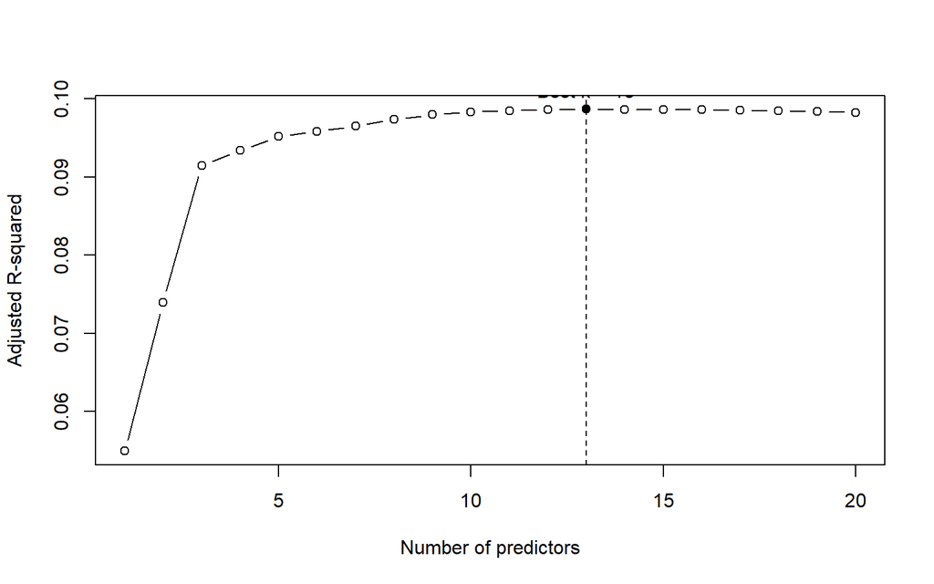

```r
#subsum$cp      # Mallows' Cp
#subsum$bic     # BIC

best_r2 <- which.max(subsum$adjr2)

best_k <- which.max(subsum$adjr2)

plot(subsum$adjr2, type = "b",
     xlab = "Number of predictors",
     ylab = "Adjusted R-squared")
abline(v = best_k, lty = 2)
points(best_k, subsum$adjr2[best_k], pch = 19)
text(best_k, subsum$adjr2[best_k],
     labels = paste0("Best k = ", best_k),
     pos = 3)
```

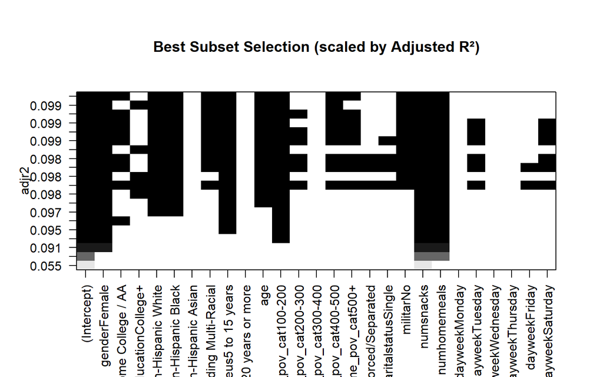

```r
best_k <- which.max(subsum$adjr2)
best_coefs <- coef(subfit, best_k)

best_tbl <- data.frame(
  term = names(best_coefs),
  estimate = unname(best_coefs),
  row.names = NULL
)

plot(subfit, scale = "adjr2")
title("Best Subset Selection (scaled by Adjusted R²)")
```

### 4.3.3 Best Model Using LASSO

We use cv.glmnet() which performs K-fold cross-validation (default: 10-fold). For each value of $\lambda$, it fits a LASSO model and computes out-of-sample mean squared error (MSE).Using lambda.1se we get the largest $\lambda$ within one standard error of the minimum MSE and therefore favors a simpler and more stable model. Under this criterion, only the number of snacks, the number of meals consumed at home, and gender are retained in the model. While this approach improves parsimony and predictive stability, it may result in underfitting and reduced interpretability, as it excludes variables, such as race and education—that previously exhibited meaningful differences in sugar consumption across categories.

```r
dffilt2 <- dffilt
names(dffilt2)[names(dffilt2) == "log_sugar"] <- "Y"
Y <- dffilt2$Y

dffilt2_complete <- na.omit(dffilt2[, c("Y","gender","education","race","maritalstatus",
                                        "timeus","income_pov_cat","militar","dayweek",
                                        "age","numsnacks","numhomemeals")])

dummies <- model.matrix(
  ~ gender + education + race + maritalstatus + timeus + income_pov_cat + militar + dayweek,
  data = dffilt2_complete
)[, -1]

dffilt_num <- data.frame(
  Y = dffilt2_complete$Y,
  dffilt2_complete[, c("timeus","age","numsnacks","numhomemeals")],
  dummies
)


x <- model.matrix(Y ~ . , data = dffilt_num)[, -1]
y <- dffilt_num$Y

cv <- cv.glmnet(x, y, alpha = 1, family = "gaussian")
coef(cv, s = "lambda.1se")
```

```
## 29 x 1 sparse Matrix of class "dgCMatrix"
##                                         lambda.1se
## (Intercept)                                4.14009
## timeus5 to 15 years                        .
## timeus20 years or more                     .
## age                                        .
## numsnacks                                  0.02894
## numhomemeals                               0.00673
## genderFemale                              -0.01002
## educationSome.College...AA                 .
## educationCollege.                          .
## raceNon.Hispanic.White                     .
## raceNon.Hispanic.Black                     .
## raceNon.Hispanic.Asian                     .
## raceOther.Race...Including.Multi.Racial    .
## maritalstatusWidowed.Divorced.Separated    .
## maritalstatusSingle                        .
## timeus5.to.15.years                        .
## timeus20.years.or.more                     .
## income_pov_cat100.200                      .
## income_pov_cat200.300                      .
## income_pov_cat300.400                      .
## income_pov_cat400.500                      .
## income_pov_cat500.                         .
## militarNo                                  .
## dayweekMonday                              .
## dayweekTuesday                             .
## dayweekWednesday                           .
## dayweekThursday                            .
## dayweekFriday                              .
## dayweekSaturday                            .
```

## 4.4 Selected Model

Using an ANOVA-based stepwise model selection approach, the final selected model is a linear regression of the logarithm of daily sugar intake on the number of snacks consumed, the number of home-prepared meals, gender, educational attainment, race and ethnicity, time residing in the United States, and the income-to-poverty ratio. This specification controls for key dietary behaviors and demographic characteristics that jointly explain variation in sugar consumption, while excluding variables that do not contribute to model fit.

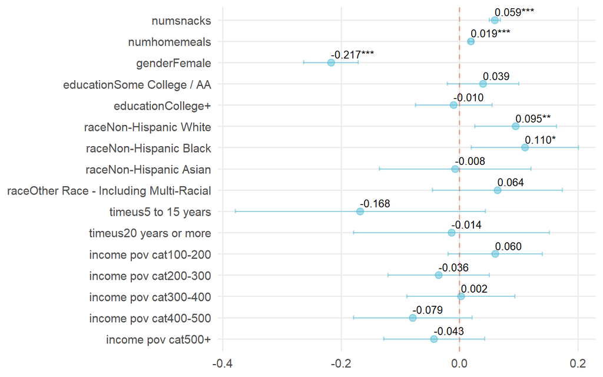

```r
dffinal=df[!is.na(df$income_pov_cat), ]
fitfinal=glm(log_sugar ~ numsnacks + numhomemeals + gender + education + race +timeus + income_pov_cat, data = dffinal)

## Coefplot
coef_df <- tidy(fitfinal, conf.int = TRUE) %>%
  filter(term != "(Intercept)") %>%
  mutate(
    # significance stars
    sig = case_when(
      p.value < 0.001 ~ "***",
      p.value < 0.01  ~ "**",
      p.value < 0.05  ~ "*",
      TRUE ~ ""
    ),
    coef_label = sprintf("%.3f%s", estimate, sig),
    term = gsub("_", " ", term),
    term = factor(term, levels = rev(unique(term)))
  )

ggplot(coef_df, aes(x = term, y = estimate)) +
  geom_point(size = 3, color = "#4DBBD5", alpha=0.5) +
  geom_errorbar(aes(ymin = conf.low, ymax = conf.high),
                width = 0.2, color = "#4DBBD5", alpha=0.5) +
  geom_hline(yintercept = 0, linetype = "dashed", alpha = 0.5, color="#E64B35") +
  geom_text(aes(label = coef_label), vjust=-0.5,
            hjust = 0, size = 3.5) +
  coord_flip() +
  labs(
    x = NULL,
    y = NULL
  ) +
  theme_minimal(base_size = 14) +
  theme(
    plot.title = element_text(face = "bold", hjust = 0.5),
    axis.title.y = element_blank(),
    panel.grid.minor = element_blank()
  )
```

The results show that a higher number of snacks was significantly associated with greater sugar intake. Specifically, each additional snack was associated with an approximately 6.1% increase in sugar intake ($\beta_{s}$ = 0.059, p < 0.001), holding all other variables constant. Similarly, each additional home-prepared meal was associated with a 1.9% increase in sugar intake ($\beta_{m}$ = 0.019, p < 0.001).

There are large gender differences in sugar intake, with females consuming significantly less sugar than males. Compared with males, females had an estimated 19.5% lower sugar intake ($\beta_{g}$ = −0.217, p < 0.001).

Educational attainment was not significantly associated with sugar intake. Compared with individuals with a high school education or less, those with some college or an associate degree had an estimated 4.0% higher sugar intake ($\beta_{e}$ = 0.039, p = 0.201), while those with a college degree or higher had a 1.0% lower sugar intake ($\beta_{g}$ = −0.010, p = 0.759).

With respect to race and ethnicity, Non-Hispanic White and Non-Hispanic Black individuals had significantly higher sugar intake compared with Hispanic individuals. Non-Hispanic White participants consumed approximately 9.9% more sugar ($\beta_{r}$ = 0.095, p = 0.007), while Non-Hispanic Black participants consumed approximately 11.7% more sugar ($\beta_{r}$ = 0.110, p = 0.017). No statistically significant differences were observed for Non-Hispanic Asian individuals or those identifying as other or multi-racial.

Time residing in the United States was not significantly associated with sugar intake. Compared with individuals who had lived in the United States for less than five years, those residing for 5–15 years had an estimated 15.5% lower sugar intake ($\beta_{tu}$ = −0.168, p = 0.119), and those residing for 20 years or more had a 1.4% lower sugar intake ($\beta_{tu}$ = −0.014, p = 0.871).

```r
r.squaredGLMM(fitfinal)
```

```
##         R2m    R2c
## [1,] 0.0997 0.0997
```

```r
#Null
pchisq(2670.1, 4237, lower.tail=F)
```

```
## [1] 1
```

```r
#Fitt
pchisq(2398.4, 4219, lower.tail=F)
```

```
## [1] 1
```

```r
#Best?
pchisq(2670.1-2398.4, 4237-4219, lower.tail=F)
```

```
## [1] 3.06e-47
```

The model has a low $R^2$ of only 0.0997 which implies that demographic characteristics fall short on explaining sugar consumption, then unobserved patterns such a behavioral variables or geography accessibility to healthy food could be omitted variables that might explain sugar consumption. Compared to the Null model, the Fitted Model was a smaller Residual deviance compared to the saturated model.

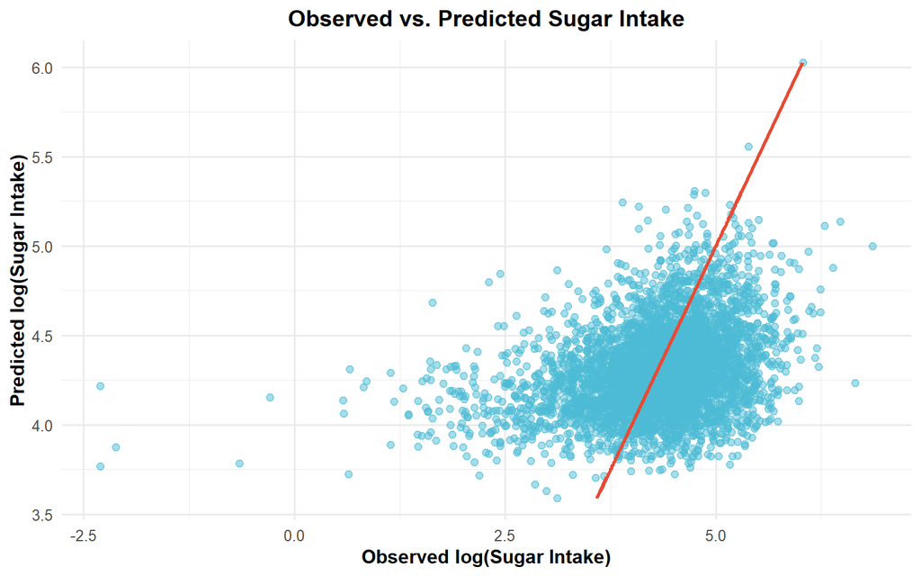

```r
# Saving the predictions:
dfwithpred <- add_predictions(dffinal,fitfinal)
#Plot predictions vs real value
ggplot(dfwithpred, aes(x = log_sugar, y = pred)) +
  geom_point(alpha = 0.5, color = "#4DBBD5", size = 2) +
  geom_line(aes(pred), colour = "#E64B35", size = 1.2) +
  labs(
    x = "Observed log(Sugar Intake)",
    y = "Predicted log(Sugar Intake)",
    title = "Observed vs. Predicted Sugar Intake"
  ) +
  theme_minimal(base_size = 12) +
  theme(
    plot.title = element_text(face = "bold", hjust = 0.5),
    axis.title = element_text(face = "bold")
  )
```

The previous plot shows how the linear model might not be the best approach for this analysis as we are very weakly predicting the sugar intake with demographic variables.

```r
check_collinearity(fitfinal)
```

```
## # Check for Multicollinearity
##
## Low Correlation
##
##            Term  VIF   VIF 95% CI adj. VIF Tolerance Tolerance 95% CI
##       numsnacks 1.12 [1.09, 1.17]     1.06      0.89     [0.86, 0.92]
##    numhomemeals 1.15 [1.12, 1.20]     1.07      0.87     [0.84, 0.90]
##          gender 1.02 [1.00, 1.10]     1.01      0.98     [0.91, 1.00]
##       education 1.46 [1.41, 1.52]     1.10      0.68     [0.66, 0.71]
##            race 1.32 [1.28, 1.38]     1.04      0.76     [0.73, 0.78]
##          timeus 1.15 [1.12, 1.20]     1.04      0.87     [0.84, 0.90]
##  income_pov_cat 1.50 [1.44, 1.56]     1.04      0.67     [0.64, 0.69]
```

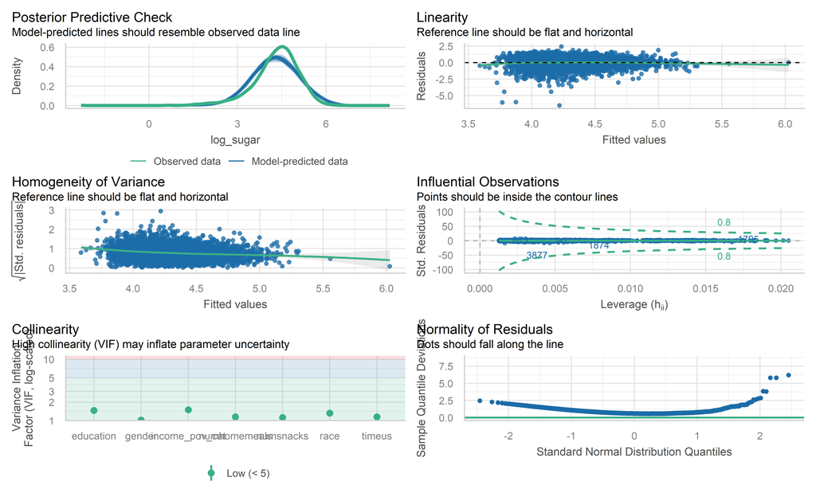

```r
check_heteroscedasticity(fitfinal)
check_model(fitfinal)
```

The Q–Q plot of the residuals reveals a substantial deviation from the 45-degree reference line in the upper tail. Specifically, the sample quantiles exceed the corresponding theoretical quantiles, indicating that the normality assumption of the residuals is violated in this model.

The Scale–Location plot further confirms the presence of heteroskedasticity, as the variance of the residuals is not constant across the range of fitted values.

The Residuals versus Leverage plot is used to identify influential observations. Although several observations exhibit relatively high residuals, none exceed the Cook’s distance threshold. This suggests that, while extreme values in sugar consumption may reduce the efficiency of the model, they are not influential enough to substantially affect the estimated coefficients or overall conclusions.

Finally, an assessment of multicollinearity indicates no cause for concern. Variance Inflation Factor (VIF) values for all independent variables are close to 1, suggesting a low degree of correlation among predictors and confirming that multicollinearity is not a significant issue in this model.

## 4.5 Conclusion Sugar Model

This study examines the demographic and behavioral correlates of daily sugar consumption using a linear regression framework with log-transformed intake. The results highlight the central role of eating behaviors in explaining variation in sugar intake. In particular, the number of snacks consumed is strongly and positively associated with sugar intake, with each additional snack corresponding to a meaningful increase in consumption. Home-prepared meals are also positively associated with sugar intake, suggesting that higher overall meal frequency may be linked to greater total sugar exposure rather than reflecting diet quality alone.

Substantial heterogeneity is observed across demographic groups. Females consume significantly less sugar than males, even after controlling for dietary behaviors and socioeconomic characteristics. Racial and ethnic differences are also evident, with Non-Hispanic White and Non-Hispanic Black individuals exhibiting higher sugar intake than Hispanic individuals. In contrast, educational attainment, time residing in the United States, and income-to-poverty ratio are not significantly associated with sugar intake in the multivariable framework. The absence of a clear income gradient suggests that economic resources alone may be insufficient to explain patterns of sugar consumption.

Despite identifying several statistically significant associations, the model explains a relatively small share of the overall variation in sugar intake. This finding indicates that demographic characteristics capture only a limited portion of the determinants of sugar consumption and points to the importance of unobserved factors such as individual preferences, dietary habits, food environments, and geographic access to healthy options. Diagnostic analyses further reveal heteroskedasticity and deviations from normality in the residuals, implying reduced efficiency of the estimates, although no influential observations are detected and multicollinearity does not appear to be a concern.

These findings have important policy implications. The lack of significant differences in sugar intake across income groups suggests that policies narrowly targeted by income may have limited effectiveness in reducing overall sugar consumption. While fiscal interventions such as sugar-sweetened beverage taxes remain a prominent policy tool((Backholer et al., 2016); (Sharma, Hauck, Hollingsworth, & Siciliani, 2014)), the results underscore the potential value of broader strategies. Interventions aimed at improving access to healthy foods((Walker, Keane, & Burke, 2010)), reducing geographic disparities in food environments((CDC, 2024)), enhancing nutrition education((Toomer, 2016); (Silva, Araújo, Lopes, & Ray, 2023)), and strengthening food labeling((Dumoitier, Abbo, Neuhofer, & McFadden, 2019)) may be more effective in addressing excessive sugar consumption at the population level. Future research incorporating behavioral measures and spatial indicators of food access could further improve understanding of the mechanisms underlying sugar intake and inform more targeted policy responses.

Backholer, K., Sarink, D., Beauchamp, A., Keating, C., Loh, V., Ball, K., Martin, J., et al. (2016). The impact of a tax on sugar-sweetened beverages according to socio-economic position: A systematic review of the evidence. *Public Health Nutrition*, *19*(17), 3070–3084. Retrieved December 12, 2025, from https://www.cambridge.org/core/journals/public-health-nutrition/article/impact-of-a-tax-on-sugarsweetened-beverages-according-to-socioeconomic-position-a-systematic-review-of-the-evidence/587CFDC392441741771A93E7F652E222

CDC. (2024, October). Get the Facts: Added Sugars. *Nutrition*. Retrieved December 12, 2025, from https://www.cdc.gov/nutrition/php/data-research/added-sugars.html

Dumoitier, A., Abbo, V., Neuhofer, Z. T., & McFadden, B. R. (2019). A review of nutrition labeling and food choice in the United States. *Obesity Science & Practice*, *5*(6), 581–591. Retrieved December 12, 2025, from https://onlinelibrary.wiley.com/doi/10.1002/osp4.374

Sharma, A., Hauck, K., Hollingsworth, B., & Siciliani, L. (2014). THE EFFECTS OF TAXING SUGAR‐SWEETENED BEVERAGES ACROSS DIFFERENT INCOME GROUPS. *Health Economics*, *23*(9), 1159–1184. Retrieved December 12, 2025, from https://onlinelibrary.wiley.com/doi/10.1002/hec.3070

Silva, P., Araújo, R., Lopes, F., & Ray, S. (2023). Nutrition and Food Literacy: Framing the Challenges to Health Communication. *Nutrients*, *15*(22), 4708. Retrieved December 12, 2025, from https://www.ncbi.nlm.nih.gov/pmc/articles/PMC10674981/

Toomer, O. (2016). Nutrition education and promotion in the U.S. *Journal of Food*, *1*(1). Retrieved December 12, 2025, from https://www.ars.usda.gov/research/publications/publication/?seqNo115=336389

U.S. Department of Agriculture, Agricultural Research Service. (2024). What We Eat in America, National Health and Nutrition Examination Survey (NHANES) August 2021-August 2023. Retrieved from https://www.ars.usda.gov/northeast-area/beltsville-md-bhnrc/beltsville-human-nutrition-research-center/food-surveys-research-group/docs/wweia-documentation-and-data-sets/

Walker, R. E., Keane, C. R., & Burke, J. G. (2010). Disparities and access to healthy food in the United States: A review of food deserts literature. *Health & Place*, *16*(5), 876–884. Retrieved December 12, 2025, from https://linkinghub.elsevier.com/retrieve/pii/S1353829210000584

Williams, A., Terry, A., Akinbami, L., Ansai, N., & Ogden, C. (2025). *What We Eat in America dietary data, NHANES: August 2021–August 2023 24-hour dietary recall interview mode change*. U.S. Department of Health; Human Services. Retrieved from https://wwwn.cdc.gov/nchs/data/Nhanes/Public/2021/Whitepapers/Aug2023-What-We-Eat-In-America-Dietary-Data-Whitepaper.pdf